# E-commerce Customer Purchase Intentions

Sümeyra Özuğur

170709046

### 1)Import “online_shoppers_intention.csv” dataset

First I should know my data. I checked Column names, row names. I checked what is in my data

```r
#import data
mydata = read.csv("C:/Users/asus/Desktop/4.Sınıf/DataScience/Midterm/online_shoppers_intention.csv")
```

Summary of dataset

```r
summary(mydata)
```

```
##  Administrative   Administrative_Duration Informational
##  Min.   : 0.000   Min.   :   0.00         Min.   : 0.0000
##  1st Qu.: 0.000   1st Qu.:   0.00         1st Qu.: 0.0000
##  Median : 1.000   Median :   7.50         Median : 0.0000
##  Mean   : 2.315   Mean   :  80.82         Mean   : 0.5036
##  3rd Qu.: 4.000   3rd Qu.:  93.26         3rd Qu.: 0.0000
##  Max.   :27.000   Max.   :3398.75         Max.   :24.0000
##  Informational_Duration ProductRelated   ProductRelated_Duration
##  Min.   :   0.00        Min.   :  0.00   Min.   :    0.0
##  1st Qu.:   0.00        1st Qu.:  7.00   1st Qu.:  184.1
##  Median :   0.00        Median : 18.00   Median :  598.9
##  Mean   :  34.47        Mean   : 31.73   Mean   : 1194.8
##  3rd Qu.:   0.00        3rd Qu.: 38.00   3rd Qu.: 1464.2
##  Max.   :2549.38        Max.   :705.00   Max.   :63973.5
##   BounceRates         ExitRates         PageValues        SpecialDay
##  Min.   :0.000000   Min.   :0.00000   Min.   :  0.000   Min.   :0.00000
##  1st Qu.:0.000000   1st Qu.:0.01429   1st Qu.:  0.000   1st Qu.:0.00000
##  Median :0.003112   Median :0.02516   Median :  0.000   Median :0.00000
##  Mean   :0.022191   Mean   :0.04307   Mean   :  5.889   Mean   :0.06143
##  3rd Qu.:0.016813   3rd Qu.:0.05000   3rd Qu.:  0.000   3rd Qu.:0.00000
##  Max.   :0.200000   Max.   :0.20000   Max.   :361.764   Max.   :1.00000
##     Month           OperatingSystems    Browser           Region
##  Length:12330       Min.   :1.000    Min.   : 1.000   Min.   :1.000
##  Class :character   1st Qu.:2.000    1st Qu.: 2.000   1st Qu.:1.000
##  Mode  :character   Median :2.000    Median : 2.000   Median :3.000
##                     Mean   :2.124    Mean   : 2.357   Mean   :3.147
##                     3rd Qu.:3.000    3rd Qu.: 2.000   3rd Qu.:4.000
##                     Max.   :8.000    Max.   :13.000   Max.   :9.000
##   TrafficType    VisitorType         Weekend         Revenue
##  Min.   : 1.00   Length:12330       Mode :logical   Mode :logical
##  1st Qu.: 2.00   Class :character   FALSE:9462      FALSE:10422
##  Median : 2.00   Mode  :character   TRUE :2868      TRUE :1908
##  Mean   : 4.07
##  3rd Qu.: 4.00
##  Max.   :20.00
```

```r
head(mydata)
```

```
##   Administrative Administrative_Duration Informational Informational_Duration
## 1              0                       0             0                      0
## 2              0                       0             0                      0
## 3              0                       0             0                      0
## 4              0                       0             0                      0
## 5              0                       0             0                      0
## 6              0                       0             0                      0
##   ProductRelated ProductRelated_Duration BounceRates ExitRates PageValues
## 1              1                0.000000  0.20000000 0.2000000          0
## 2              2               64.000000  0.00000000 0.1000000          0
## 3              1                0.000000  0.20000000 0.2000000          0
## 4              2                2.666667  0.05000000 0.1400000          0
## 5             10              627.500000  0.02000000 0.0500000          0
## 6             19              154.216667  0.01578947 0.0245614          0
##   SpecialDay Month OperatingSystems Browser Region TrafficType
## 1          0   Feb                1       1      1           1
## 2          0   Feb                2       2      1           2
## 3          0   Feb                4       1      9           3
## 4          0   Feb                3       2      2           4
## 5          0   Feb                3       3      1           4
## 6          0   Feb                2       2      1           3
##         VisitorType Weekend Revenue
## 1 Returning_Visitor   FALSE   FALSE
## 2 Returning_Visitor   FALSE   FALSE
## 3 Returning_Visitor   FALSE   FALSE
## 4 Returning_Visitor   FALSE   FALSE
## 5 Returning_Visitor    TRUE   FALSE
## 6 Returning_Visitor   FALSE   FALSE
```

```r
#tail(mydata)
```

```r
sum(is.na(mydata))#0 is there na or not
```

```
## [1] 0
```

```r
colnames(mydata)
```

```
##  [1] "Administrative"          "Administrative_Duration"
##  [3] "Informational"           "Informational_Duration"
##  [5] "ProductRelated"          "ProductRelated_Duration"
##  [7] "BounceRates"             "ExitRates"
##  [9] "PageValues"              "SpecialDay"
## [11] "Month"                   "OperatingSystems"
## [13] "Browser"                 "Region"
## [15] "TrafficType"             "VisitorType"
## [17] "Weekend"                 "Revenue"
```

```r
#row.names(mydata)
```

# Data

The dataset consists of users 12330 and there are 18 attributes in the dataset. 10 of them have Numerical features, rest of them have Categorical features

### Numerical features:

Administrative, Informational, Product related, Bounce rate, Exit rate,Page value, Special day

### Categorical features:

VisitorType,Region, Browser, Operating Systems, TrafficType, Weekend, Month, Revenue

## Required Libraries

```r
library(ggplot2)
library(plyr)
library(dplyr)
library(funModeling)
library(ggbiplot)
library(tidyverse)  # data manipulation
library(cluster)    # clustering algorithms
library(factoextra) # clustering algorithms &
```

I drew some graphs to **better understand** my data

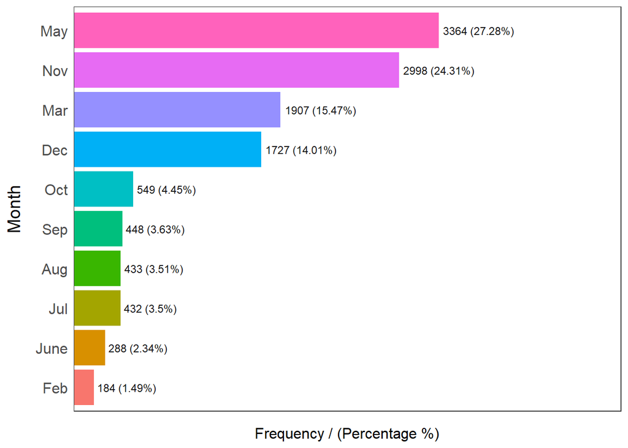

```
##    Month frequency percentage cumulative_perc
## 1    May      3364      27.28           27.28
## 2    Nov      2998      24.31           51.59
## 3    Mar      1907      15.47           67.06
## 4    Dec      1727      14.01           81.07
## 5    Oct       549       4.45           85.52
## 6    Sep       448       3.63           89.15
## 7    Aug       433       3.51           92.66
## 8    Jul       432       3.50           96.16
## 9   June       288       2.34           98.50
## 10   Feb       184       1.49          100.00
```

```r
a <-  mydata %>% select(Month)

freq(a)
```

As you see data of 27.28% of people were kept in May, data of 24.31% of people were kept in Nov, data of 15.47% of people were kept in Mar, and so on.

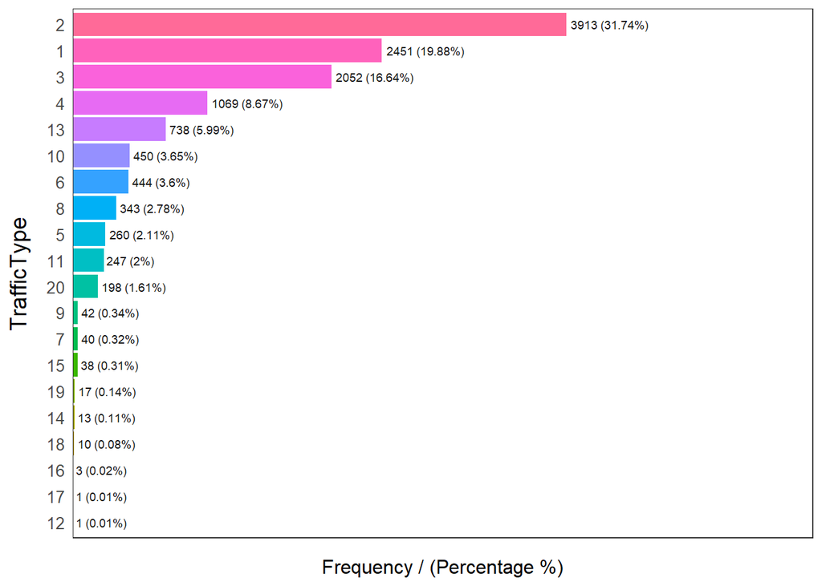

```
##    TrafficType frequency percentage cumulative_perc
## 1            2      3913      31.74           31.74
## 2            1      2451      19.88           51.62
## 3            3      2052      16.64           68.26
## 4            4      1069       8.67           76.93
## 5           13       738       5.99           82.92
## 6           10       450       3.65           86.57
## 7            6       444       3.60           90.17
## 8            8       343       2.78           92.95
## 9            5       260       2.11           95.06
## 10          11       247       2.00           97.06
## 11          20       198       1.61           98.67
## 12           9        42       0.34           99.01
## 13           7        40       0.32           99.33
## 14          15        38       0.31           99.64
## 15          19        17       0.14           99.78
## 16          14        13       0.11           99.89
## 17          18        10       0.08           99.97
## 18          16         3       0.02           99.99
## 19          12         1       0.01          100.00
## 20          17         1       0.01          100.00
```

```r
mydata$TrafficType<- as.factor(mydata$TrafficType)
a <-  mydata %>% select( TrafficType)

freq(a)
```

31.74% of my data set is type 2,  
19.88% of my data set is type 1, 16.64% of my data set is type 3 and so on.

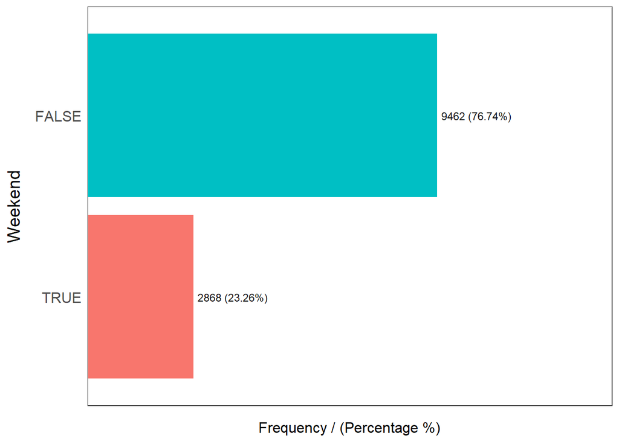

```
##   Weekend frequency percentage cumulative_perc
## 1   FALSE      9462      76.74           76.74
## 2    TRUE      2868      23.26          100.00
```

```r
#VisitorType,Weekend,
mydata$Weekend<- as.factor(mydata$Weekend)
a <-  mydata %>% select( Weekend)
freq(a)
```

76.74% of the people is accessing the site during the week, 23.26% of people enter the site on the weekend.

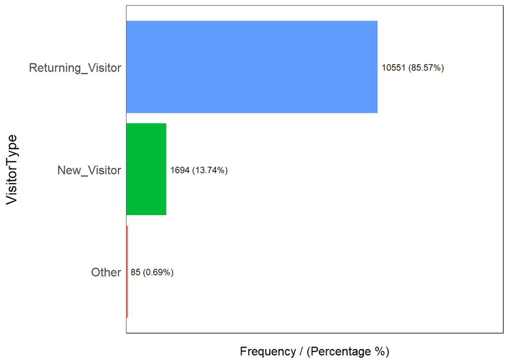

```
##         VisitorType frequency percentage cumulative_perc
## 1 Returning_Visitor     10551      85.57           85.57
## 2       New_Visitor      1694      13.74           99.31
## 3             Other        85       0.69          100.00
```

```r
#VisitorTy,Weekend,
mydata$VisitorType<- as.factor(mydata$VisitorType)
a <-  mydata %>% select(VisitorType)
freq(a)
```

The number of Returning_customers in this site is 10551, The number of New_Visitor in this site is 1694 and The number of Other entering this site is 85.

```r
mydata2 <- select(mydata, -Revenue )
mydata2 <- transform(mydata2, Month = as.integer(mapvalues(Month,c("Jan" ,"Feb","Mar", "Apr","May","June","Jul","Aug","Sep","Oct","Nov","Dec"), c(1,2,3,4,5,6,7,8,9,10,11,12))),
                     VisitorType=as.integer(mapvalues(VisitorType,c("Returning_Visitor","New_Visitor","Other"),c(1,2,3))),
                     Weekend=as.integer(mapvalues(Weekend,c(TRUE,FALSE),c(1,0))),
TrafficType=as.integer(TrafficType)
                     )
#view(mydata2)
cor(mydata2)
```

```
##                         Administrative Administrative_Duration Informational
## Administrative             1.000000000             0.601583342   0.376850429
## Administrative_Duration    0.601583342             1.000000000   0.302709709
## Informational              0.376850429             0.302709709   1.000000000
## Informational_Duration     0.255848140             0.238030789   0.618954862
## ProductRelated             0.431119340             0.289086621   0.374164291
## ProductRelated_Duration    0.373939013             0.355421954   0.387505306
## BounceRates               -0.223562630            -0.144170410  -0.116113616
## ExitRates                 -0.316482998            -0.205797757  -0.163666061
## PageValues                 0.098989585             0.067608481   0.048631692
## SpecialDay                -0.094777598            -0.073303725  -0.048219254
## Month                      0.096712834             0.057884589   0.063499805
## OperatingSystems          -0.006347063            -0.007343418  -0.009526668
## Browser                   -0.025034572            -0.015391527  -0.038234678
## Region                    -0.005486805            -0.005560563  -0.029168638
## TrafficType               -0.033560713            -0.014376431  -0.034490754
## VisitorType               -0.025819710            -0.023939717   0.055827573
## Weekend                    0.026416750             0.014990142   0.035784725
##                         Informational_Duration ProductRelated
## Administrative                     0.255848140    0.431119340
## Administrative_Duration            0.238030789    0.289086621
## Informational                      0.618954862    0.374164291
## Informational_Duration             1.000000000    0.280046268
## ProductRelated                     0.280046268    1.000000000
## ProductRelated_Duration            0.347363577    0.860926836
## BounceRates                       -0.074066610   -0.204577633
## ExitRates                         -0.105275683   -0.292526283
## PageValues                         0.030860874    0.056281794
## SpecialDay                        -0.030576549   -0.023958175
## Month                              0.044354275    0.156021711
## OperatingSystems                  -0.009578676    0.004289621
## Browser                           -0.019284981   -0.013145721
## Region                            -0.027144112   -0.038121842
## TrafficType                       -0.024674908   -0.043064304
## VisitorType                        0.044676760    0.126655811
## Weekend                            0.024078486    0.016091964
##                         ProductRelated_Duration  BounceRates    ExitRates
## Administrative                      0.373939013 -0.223562630 -0.316482998
## Administrative_Duration             0.355421954 -0.144170410 -0.205797757
## Informational                       0.387505306 -0.116113616 -0.163666061
```

[output cut: 53 more lines]

```
## Informational            0.0357847251
## Informational_Duration   0.0240784862
## ProductRelated           0.0160919642
## ProductRelated_Duration  0.0073106138
## BounceRates             -0.0465139965
## ExitRates               -0.0625870480
## PageValues               0.0120016392
## SpecialDay              -0.0167671553
## Month                    0.0171498666
## OperatingSystems         0.0002842506
## Browser                 -0.0402608638
## Region                  -0.0006906703
## TrafficType             -0.0022212292
## VisitorType             -0.0436792493
## Weekend                  1.0000000000
```

there is a relation **Administrative and Administrative_Duration**(0,60), there is a relation **Informational_Duration and Informational**(0,61) there is a relation **ProductRelated_Duration and ProductRelated**(0,86) there is a relation **ExitRates and BounceRates**(0,91)

And then I looked at the variances of some columns of my data

```r
 mydata2 %>%
summarise("Administrative"= var(Administrative,na.rm = TRUE),
          "Administrative_Duration"=var(Administrative_Duration,na.rm = TRUE),
          "Informational"=var(Informational,na.rm = TRUE),
          "Informational_Duration" =var(Informational_Duration,na.rm = TRUE),
          "ProductRelated" =var(ProductRelated,na.rm = TRUE),
          "ProductRelated_Duration" =var(ProductRelated_Duration,na.rm = TRUE),
          "BounceRates" = var(BounceRates,na.rm = TRUE),
          "ExitRates" =var(ExitRates,na.rm = TRUE),
          "PageValues" =var(PageValues,na.rm = TRUE),
          "SpecialDay" =var(SpecialDay,na.rm = TRUE),
          "OperatingSystems" =var(OperatingSystems,na.rm = TRUE),
          "Browser" =var(Browser,na.rm = TRUE),
          "Region" =var(Region,na.rm = TRUE),
          "TrafficType" =var(TrafficType, na.rm = TRUE)


          )
```

```
##   Administrative Administrative_Duration Informational Informational_Duration
## 1       11.03425                31250.85      1.613297               19810.36
##   ProductRelated ProductRelated_Duration BounceRates   ExitRates PageValues
## 1        1978.07                 3662130 0.002351117 0.002361624   344.7868
##   SpecialDay OperatingSystems  Browser  Region TrafficType
## 1 0.03956808        0.8305129 2.949039 5.76764    16.20199
```

Since “Exit Rates” , “BounceRates” and “SpecialDay” variance is too low, I am removing it from my data. By the way, the variance in the Operating System is low because the numbers here refer to an operating system, so I’m not removing it.

```r
#mydata2
mydata3 <- select(mydata2,-ExitRates, -SpecialDay, -BounceRates )
head(mydata3)
```

```
##   Administrative Administrative_Duration Informational Informational_Duration
## 1              0                       0             0                      0
## 2              0                       0             0                      0
## 3              0                       0             0                      0
## 4              0                       0             0                      0
## 5              0                       0             0                      0
## 6              0                       0             0                      0
##   ProductRelated ProductRelated_Duration PageValues Month OperatingSystems
## 1              1                0.000000          0     2                1
## 2              2               64.000000          0     2                2
## 3              1                0.000000          0     2                4
## 4              2                2.666667          0     2                3
## 5             10              627.500000          0     2                3
## 6             19              154.216667          0     2                2
##   Browser Region TrafficType VisitorType Weekend
## 1       1      1           1           3       1
## 2       2      1           2           3       1
## 3       1      9           3           3       1
## 4       2      2           4           3       1
## 5       3      1           4           3       2
## 6       2      1           3           3       1
```

Purpose:

I want to do analysis for intention of online shoppers on Weekends of May

```r
newData <- mydata3 %>%
  filter(Weekend == TRUE, Month == 5) %>%
  select(Administrative, Informational, ProductRelated ,OperatingSystems, Browser, Region, TrafficType, VisitorType)


head(newData)
```

```
##   Administrative Informational ProductRelated OperatingSystems Browser Region
## 1              0             0             15                3       2      4
## 2              0             0             24                3       2      1
## 3              2             1             95                2       2      1
## 4              0             0              4                2       2      4
## 5              0             0             77                2       2      3
## 6              0             0            130                3       2      6
##   TrafficType VisitorType
## 1           4           3
## 2           2           3
## 3           6           3
## 4          13           3
## 5           6           3
## 6          13           3
```

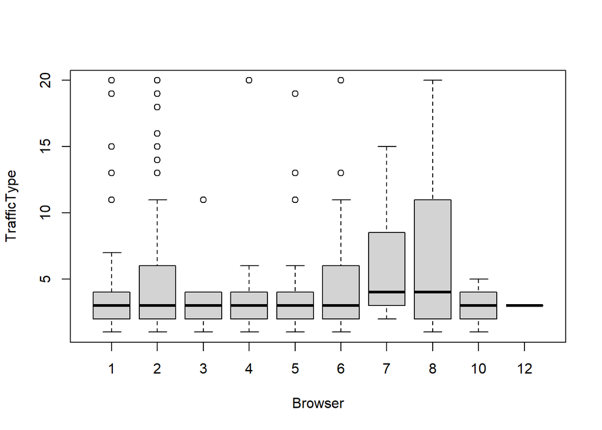

```r
boxplot(TrafficType ~ Browser , data = newData)
```

```r
# TrafficType Browser e göre grupladım
```

I grouped Traffic Type **by Browser**. As you see The heights of 3,4,5 and 10 are close each other. medians of 1,2,3,4,5,10 are similar

# PCA

```r
sumeyra_pca <- prcomp(newData, center = TRUE, scale. = TRUE)
summary(sumeyra_pca)
```

```
## Importance of components:
##                           PC1    PC2    PC3    PC4    PC5    PC6     PC7
## Standard deviation     1.3502 1.0962 1.0252 0.9989 0.9857 0.9007 0.82506
## Proportion of Variance 0.2279 0.1502 0.1314 0.1247 0.1215 0.1014 0.08509
## Cumulative Proportion  0.2279 0.3781 0.5095 0.6342 0.7557 0.8571 0.94215
##                            PC8
## Standard deviation     0.68031
## Proportion of Variance 0.05785
## Cumulative Proportion  1.00000
```

When I look at my PCA analysis results, PC1, PC2, PC3, PC4, PC5 is enough for me. total of variance of them is 0.7557.

The variances of my pca analysis are show in the image below.

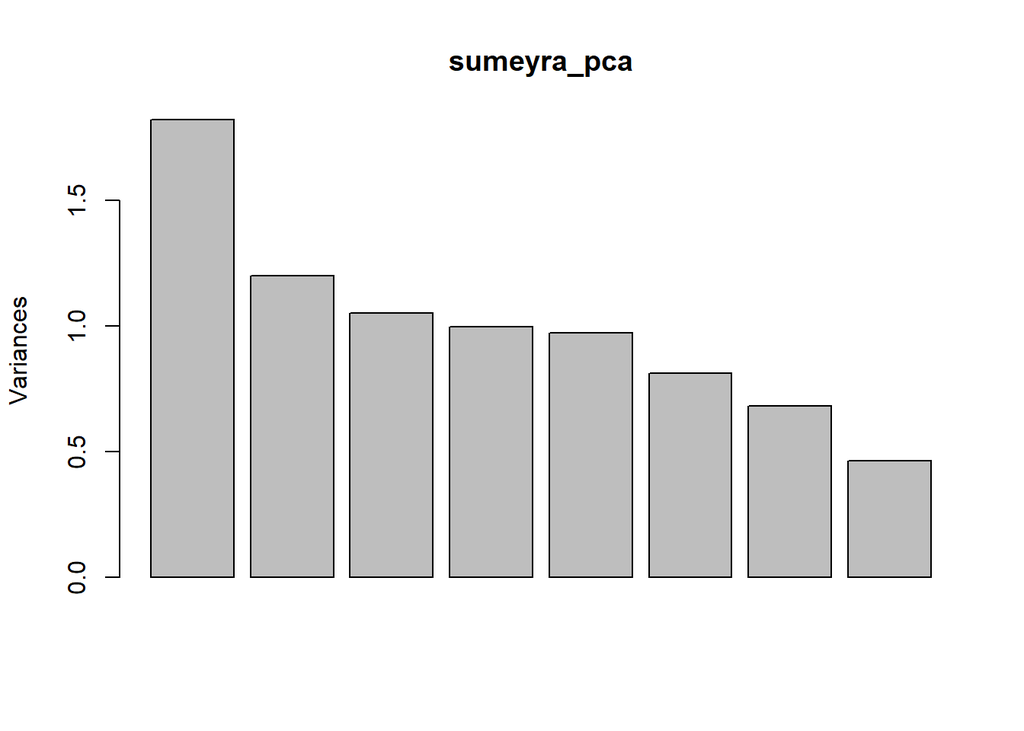

```r
screeplot(sumeyra_pca)
```

```r
sumeyra <- transform(newData, VisitorType =as.factor(VisitorType))
```

It had to be a factor type in order to do the visulation, so I converted “VisitorType” to factor type

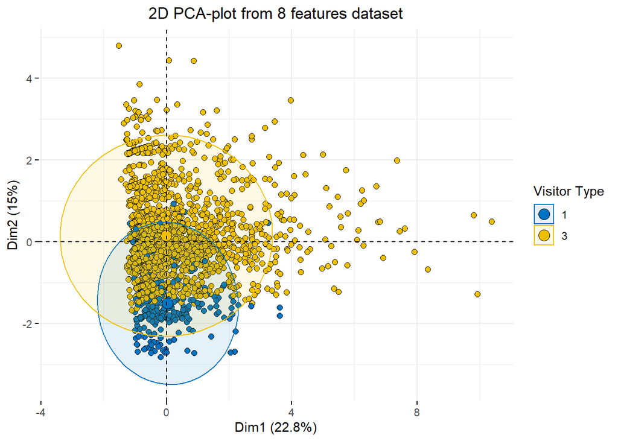

```r
fviz_pca_ind(sumeyra_pca, geom.ind = "point", pointshape = 21,
             pointsize = 2,
             fill.ind = sumeyra$VisitorType,
             col.ind = "black",
             palette = "jco",
             addEllipses = TRUE,
             label = "var",
             col.var = "black",
             repel = TRUE,
             legend.title = "Visitor Type") +
  ggtitle("2D PCA-plot from 8 features dataset") +
  theme(plot.title = element_text(hjust = 0.5))
```

As you see ,We cannot make a clear distinction between clusters, But I can say “visitor type 3” spread more. By the way Dim1 and Dim2 come from this principal component. Reducing to size.

# K-MEANS

First of all, I’ve run my Kmeans algorithm for a K value I have given.

```r
modelData <- kmeans(newData, centers = 3, nstart = 25)
head(modelData)
```

```
## $cluster
##    [1] 1 1 3 1 2 3 1 1 1 1 1 2 1 1 1 3 1 2 2 2 1 1 2 1 1 1 2 1 1 1 1 1 2 1 1 1 1
##   [38] 1 2 1 1 1 1 1 1 1 1 1 2 1 1 1 1 1 1 1 1 2 1 1 1 1 1 1 2 1 1 1 2 1 1 1 1 1
##   [75] 1 2 1 3 1 1 2 1 1 1 1 1 2 1 2 2 1 1 1 1 1 1 2 2 1 2 1 1 2 1 1 1 1 2 1 1 1
##  [112] 1 1 2 1 1 1 3 2 1 1 2 1 1 1 1 1 3 3 1 2 1 1 1 1 1 1 1 1 1 1 1 2 1 1 1 1 1
##  [149] 1 2 1 1 1 2 3 1 2 1 1 1 2 1 1 1 2 2 1 1 1 1 1 2 2 1 1 1 2 1 1 1 1 1 1 1 1
##  [186] 1 1 1 1 2 1 1 1 1 1 1 1 1 1 1 1 1 1 1 1 1 1 1 1 2 2 1 2 1 1 1 1 1 2 1 2 1
##  [223] 1 2 1 1 1 1 1 2 2 1 1 2 2 2 1 1 1 1 1 2 2 2 1 1 1 1 3 1 1 2 1 3 2 1 2 1 1
##  [260] 1 1 2 1 2 1 1 1 1 1 1 1 1 1 1 1 1 1 1 1 1 1 1 1 1 1 1 1 1 3 1 1 1 1 1 1 1
##  [297] 2 2 1 1 2 1 2 2 1 1 1 1 1 2 2 1 1 1 1 1 1 1 1 1 2 1 2 1 1 1 1 1 1 2 1 1 1
##  [334] 1 1 1 1 1 2 1 1 3 1 1 1 2 1 1 1 2 1 2 2 1 1 2 1 1 1 1 2 1 2 1 1 1 1 1 1 2
##  [371] 3 1 1 1 3 1 1 1 1 1 1 1 1 1 1 1 1 2 1 1 2 1 2 1 1 3 1 1 1 1 2 1 1 1 1 1 2
##  [408] 1 1 1 1 1 1 1 1 1 1 2 1 1 1 2 1 1 1 1 3 1 1 2 1 1 1 1 3 1 1 2 2 2 1 1 1 1
##  [445] 1 2 1 1 2 1 2 1 1 2 1 1 1 1 1 1 1 1 1 1 2 1 1 1 1 1 1 1 1 2 1 2 1 1 1 1 2
##  [482] 1 1 1 1 1 1 1 1 1 1 1 2 1 1 1 1 1 1 2 2 1 1 1 1 2 1 1 1 1 1 1 1 1 1 2 2 1
```

[output cut: 80 more lines]

Now let’s make a visualization to understand the number of clusters.

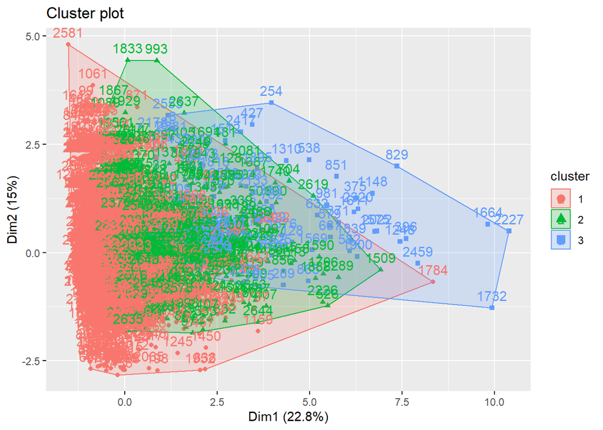

```r
fviz_cluster(modelData , data =newData)
```

According to this picture, I guess 3 of classification is a correct choice.

```r
#modelData$withinss
#modelData$tot.withinss
```

# Elbow

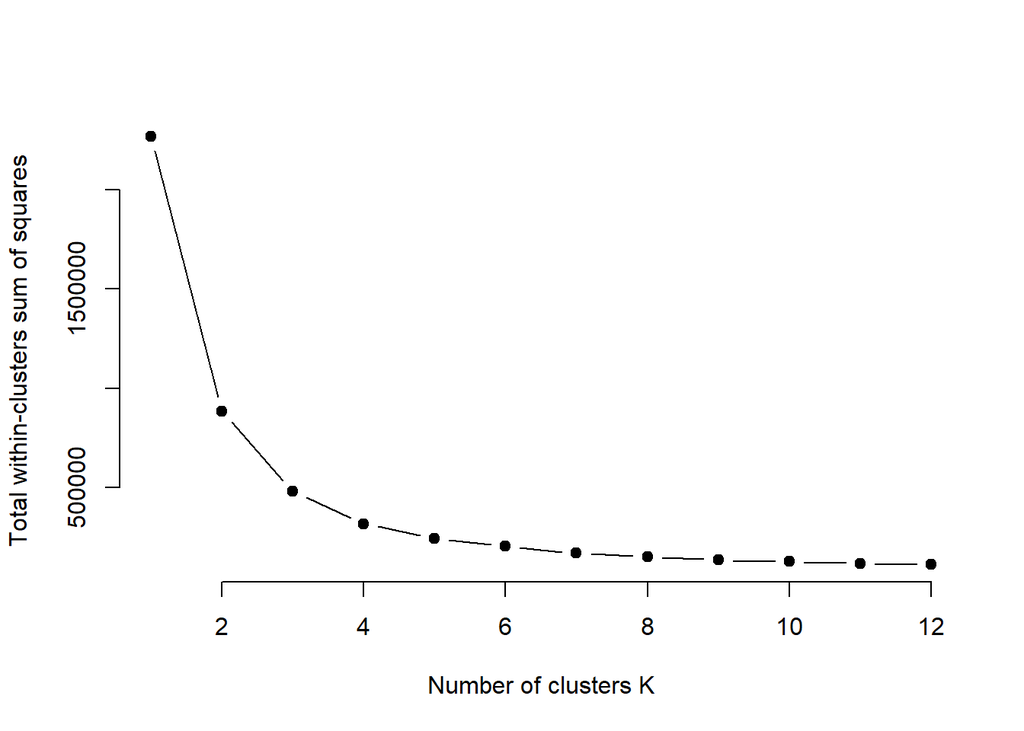

```r
set.seed(123)

# function to compute total within-cluster sum of square
wss <- function(k) {
  kmeans(newData, k, nstart = 10 )$tot.withinss
}

# Compute and plot wss for k = 1 to k = 15
k.values <- 1:12

# extract wss for 2-15 clusters
wss_values <- map_dbl(k.values, wss)

plot(k.values, wss_values,
       type="b", pch = 19, frame = FALSE,
       xlab="Number of clusters K",
       ylab="Total within-clusters sum of squares")
```

According to the elbow rule, the optimum K should be 4

# Hierarchical Clustering

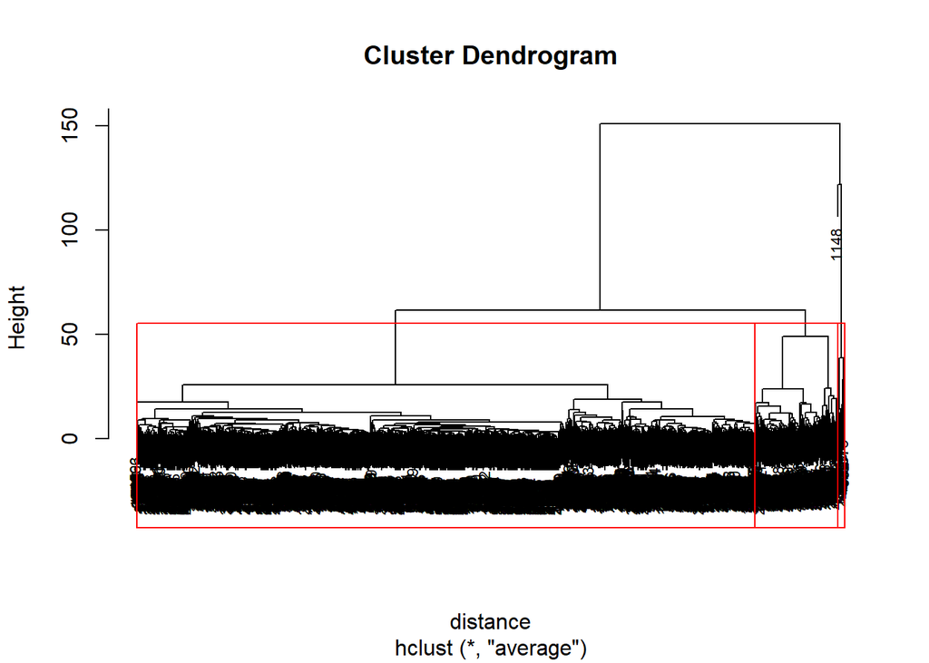

```r
distance <- dist(newData, method="euclidean")
hier <- hclust(distance, method="average")
plot(hier, cex=0.7)
rect.hclust(hier, k=4, border="red")
```

```r
hier_cut <- cutree(hier, 4)
```

Another cluster’s algorithm is Hierarchical Clustering. There is a visualization called dendogram, in Hierarchical Clustering.

I ran this algorithm for k value 4.